# Practica 2: Manejo de datos en R

Analisis descriptivo de datos

Emmanuel Garduño Téllez

Estadistica Comutacional

#personalizar nuestra seccion

```r
options(digits=3,papersize = "letter")
# https://stat.ethz.ch/R-manual/R-devel/library/base/html/options.html


# Opciones globales en graficas
par(mar=c(5.1,5,4.1,2.1),font=3,family="sans",bg="yellow")
```

# 1 [10 puntos] Presentación

## 1.1 Explica el contexto del problema que vas a analizar y el por qué están incluidas esas variables en la base de datos elegida [no olvides citar a la fuente de información].

Por motivos personales, quiero analizar una base de datos centrada en videojuegos, para analizar y ver cómo está creciendo dicha industria, basándome en los datos recolectados. El CSV, fue encontrado en: https://www.kaggle.com/sidtwr/videogames-sales-dataset, página web centrada en data science, donde se suben pruebas y archivos con bases de datos de todo tipo. Las variables de interés para esta práctica son:

- Platform: Plataforma donde salió el videojuego
- Year_of_Release: Año de salida
- Genere: Genero asociado al juego principalmente
- Publisher: Empresa que publicaba el videojuego
- Global_Sales: Ventas globales (en millones de dólares)
- Critic_Score: Evaluacion de la crítica de 0 a 100
- Rating: Clasificación por edades

# 2 [20 puntos] Manejo de datos

Antes de empezar a manipular los datos se procederá a limpiarlo antes de unos N/A distintos que aparecen como información, Estos N/A “existentes” se encuentran en Publisher

```r
setwd("C:/Users/Emman/Documents/CCH-N} FES-A/fessaa/FES/7mo semestre/Temas Selectos de Estadistica")
library(readr)
Video_Games <- read_csv("./DATA/Video_Games_Sales_as_at_22_Dec_2016.csv",
                                                col_types = cols(Year_of_Release = col_number()),
                                                na = c("NA","N/A", "")) #Diferentes tipos de N/A
head(Video_Games)    # ver los primeros 6 renglones del conjunto de datos
```

```
## # A tibble: 6 x 16
##   Name      Platform Year_of_Release Genre  Publisher NA_Sales EU_Sales JP_Sales
##   <chr>     <chr>              <dbl> <chr>  <chr>        <dbl>    <dbl>    <dbl>
## 1 Wii Spor~ Wii                 2006 Sports Nintendo      41.4    29.0      3.77
## 2 Super Ma~ NES                 1985 Platf~ Nintendo      29.1     3.58     6.81
## 3 Mario Ka~ Wii                 2008 Racing Nintendo      15.7    12.8      3.79
## 4 Wii Spor~ Wii                 2009 Sports Nintendo      15.6    10.9      3.28
## 5 Pokemon ~ GB                  1996 Role-~ Nintendo      11.3     8.89    10.2
## 6 Tetris    GB                  1989 Puzzle Nintendo      23.2     2.26     4.22
## # ... with 8 more variables: Other_Sales <dbl>, Global_Sales <dbl>,
## #   Critic_Score <dbl>, Critic_Count <dbl>, User_Score <dbl>, User_Count <dbl>,
## #   Developer <chr>, Rating <chr>
```

```r
tail(Video_Games)    # ver los ultimos 6 renglones del conjunto de datos
```

```
## # A tibble: 6 x 16
##   Name       Platform Year_of_Release Genre Publisher NA_Sales EU_Sales JP_Sales
##   <chr>      <chr>              <dbl> <chr> <chr>        <dbl>    <dbl>    <dbl>
## 1 SCORE Int~ PS2                 2008 Raci~ Activisi~     0        0        0
## 2 Samurai W~ PS3                 2016 Acti~ Tecmo Ko~     0        0        0.01
## 3 LMA Manag~ X360                2006 Spor~ Codemast~     0        0.01     0
## 4 Haitaka n~ PSV                 2016 Adve~ Idea Fac~     0        0        0.01
## 5 Spirits &~ GBA                 2003 Plat~ Wanadoo       0.01     0        0
## 6 Winning P~ PSV                 2016 Simu~ Tecmo Ko~     0        0        0.01
## # ... with 8 more variables: Other_Sales <dbl>, Global_Sales <dbl>,
## #   Critic_Score <dbl>, Critic_Count <dbl>, User_Score <dbl>, User_Count <dbl>,
## #   Developer <chr>, Rating <chr>
```

## 2.1 Edita el nombre de todas las columnas y cambia el orden de las mismas (como lo visto en clase). Guardarlo con otro nombre, por ejemplo, datosordenados.txt. El formato del archivo puede ser .csv,.txt,.xls,.dat

```r
library(janitor)
datosV<- clean_names(Video_Games)
names(Video_Games) #Limpia nombres
```

```
##  [1] "Name"            "Platform"        "Year_of_Release" "Genre"
##  [5] "Publisher"       "NA_Sales"        "EU_Sales"        "JP_Sales"
##  [9] "Other_Sales"     "Global_Sales"    "Critic_Score"    "Critic_Count"
## [13] "User_Score"      "User_Count"      "Developer"       "Rating"
```

```r
names(datosV)
```

```
##  [1] "name"            "platform"        "year_of_release" "genre"
##  [5] "publisher"       "na_sales"        "eu_sales"        "jp_sales"
##  [9] "other_sales"     "global_sales"    "critic_score"    "critic_count"
## [13] "user_score"      "user_count"      "developer"       "rating"
```

```r
library(dplyr)
datosV.a<- select(datosV, platform, year_of_release, genre, publisher, global_sales, critic_score, rating, developer, everything())
names(datosV.a) #Reorganizo columnas para mi comodidad
```

```
##  [1] "platform"        "year_of_release" "genre"           "publisher"
##  [5] "global_sales"    "critic_score"    "rating"          "developer"
##  [9] "name"            "na_sales"        "eu_sales"        "jp_sales"
## [13] "other_sales"     "critic_count"    "user_score"      "user_count"
```

```r
write.csv(datosV.a, file = "./DATA/DatosVideojuego.csv") #Guardo un documento con las columnas cambiadas
```

## 2.2 Separa las variables cualitativas de las cuantitativas y guarda cada grupo con un nombre distinto.

```r
datosV.a.n<- select(datosV.a,where(is.numeric)) #Variables númericas
head(datosV.a.n)
```

```
## # A tibble: 6 x 10
##   year_of_release global_sales critic_score na_sales eu_sales jp_sales
##             <dbl>        <dbl>        <dbl>    <dbl>    <dbl>    <dbl>
## 1            2006         82.5           76     41.4    29.0      3.77
## 2            1985         40.2           NA     29.1     3.58     6.81
## 3            2008         35.5           82     15.7    12.8      3.79
## 4            2009         32.8           80     15.6    10.9      3.28
## 5            1996         31.4           NA     11.3     8.89    10.2
## 6            1989         30.3           NA     23.2     2.26     4.22
## # ... with 4 more variables: other_sales <dbl>, critic_count <dbl>,
## #   user_score <dbl>, user_count <dbl>
```

```r
datosV.a.c<- select(datosV.a,where(is.character)) #Variables caracteres
head(datosV.a.c)
```

```
## # A tibble: 6 x 6
##   platform genre        publisher rating developer name
##   <chr>    <chr>        <chr>     <chr>  <chr>     <chr>
## 1 Wii      Sports       Nintendo  E      Nintendo  Wii Sports
## 2 NES      Platform     Nintendo  <NA>   <NA>      Super Mario Bros.
## 3 Wii      Racing       Nintendo  E      Nintendo  Mario Kart Wii
## 4 Wii      Sports       Nintendo  E      Nintendo  Wii Sports Resort
## 5 GB       Role-Playing Nintendo  <NA>   <NA>      Pokemon Red/Pokemon Blue
## 6 GB       Puzzle       Nintendo  <NA>   <NA>      Tetris
```

# 3 [50 puntos] Datos faltantes e imputación

## 3.1 Revisa el contenido de la base de datos e indica si tienes presencia de datos faltantes en alguna(s) variable(s). Puedes utilizar las funciones vistas en R para realizarlo.

para ello usaremos la librería naniar

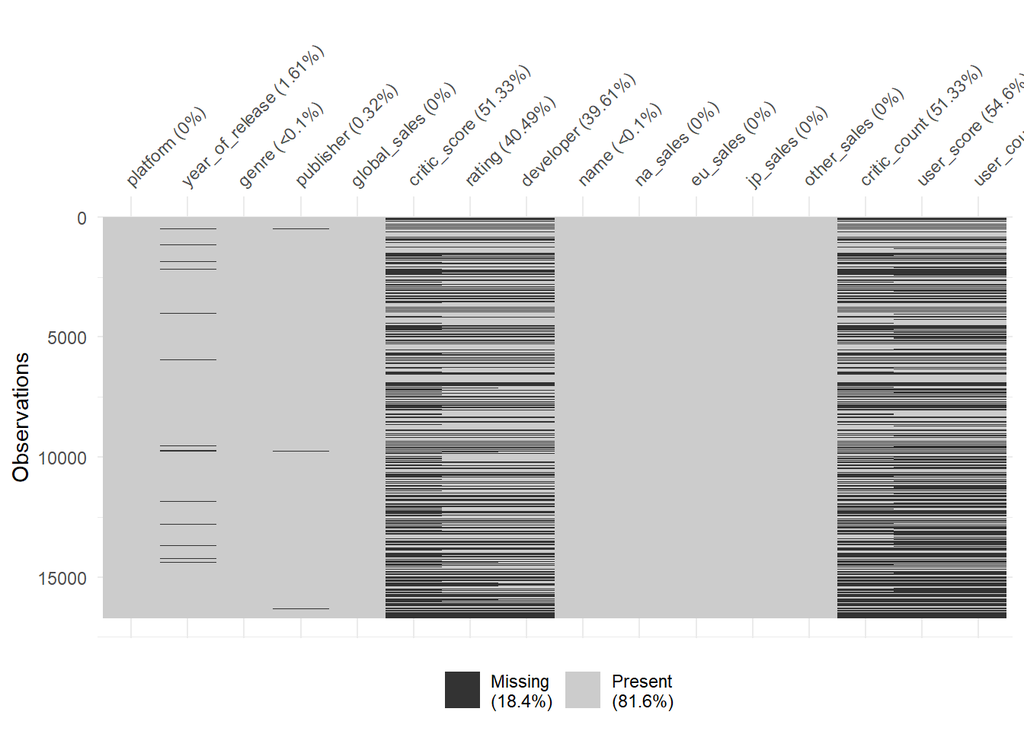

```r
library(naniar)
vis_miss(datosV.a)
```

```r
#Nota: las lineas negras indican la posicion del dato faltante en cada columna
```

Si hay datos faltantes.

## 3.2 Identifica el tipo de patrón de datos faltantes con alguna de las técnicas discutidas en clase. Explica tus hallazgos lo más detallado posible.

A primera vista no se ve nada relevante, a menos que arreglemos el data frame con respecto a la plataforma y en orden los nombres de los juegos

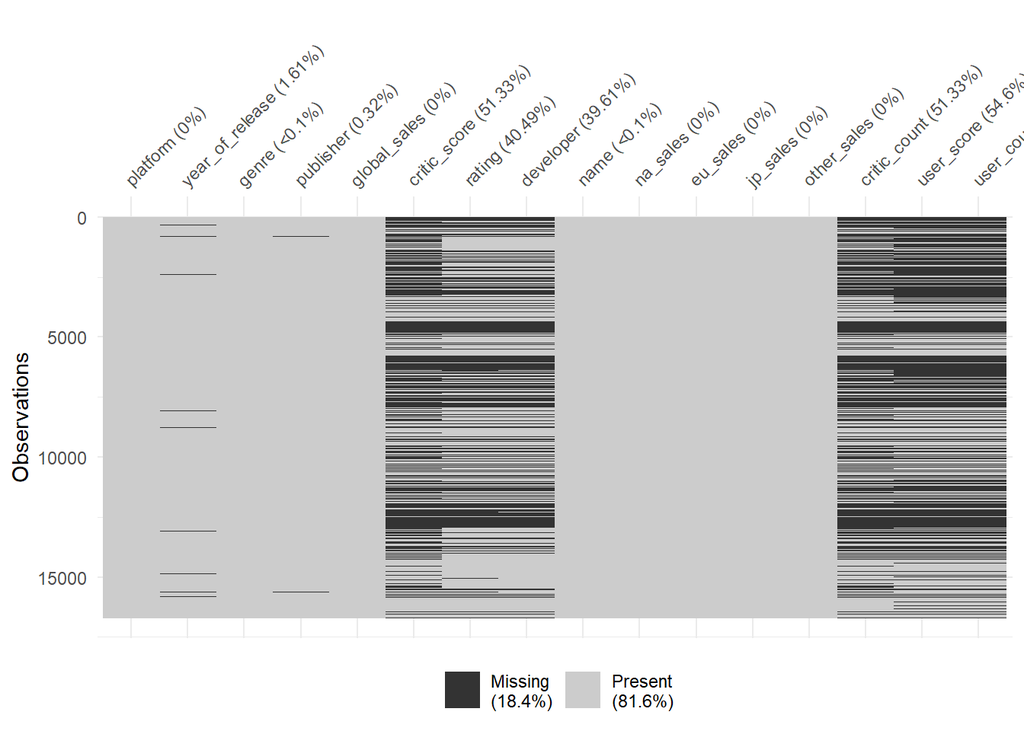

```r
datosV.a.plataforma.nombre <- arrange(datosV.a, platform, name)
vis_miss(datosV.a.plataforma.nombre)
```

Con ello y revisando los datos, se alcanza a ver que ciertos juegos no tienen una puntuación de critica o clasificación de edad, esto se debe a ser juegos de series animadas o de nicho para ciertos países. También se alcanza a observar que el deverloper cuando no existe, por lo regular es la misma empresa que es su publisher la que hace esta labor. Por tanto, se puede decir que sus datos faltantes son tipo MAR

## 3.3 Utiliza el método de imputación simple (con el criterio de la media) para completar la información. Guarda con otro nombre esta base de datos, ya que se utilizará más adelante.

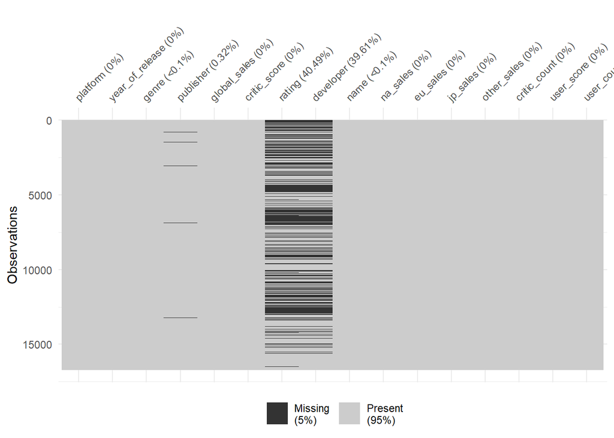

```r
library(mice)
set.seed(4444)
imputed= mice(datosV.a.plataforma.nombre, m=1, defaultMethod = "pmm")
datosV.imp = complete(imputed)
vis_miss(datosV.imp)
```

## 3.4 Si la base de datos está originalmente completa, entonces elige 2 ó 3 variables (cuantitativas) y realiza lo siguiente:

1. Simula un patrón MCAR del 15% de valores faltantes en cada una.
2. Verifica mediante un método gráfico o inferencial (de los estudiados en clase) que el patrón de faltantes es MCAR.
3. Imputa (con el criterio de la media) los valores faltantes y guarda esta nueva base datos con otro nombre.

## 3.5 A partir de la base de datos “incompleta” compara los siguientes métodos de imputación del paquete mice: sample, norm.nob, cart, rf. La comparación puedes hacerla con marginplot, o bien, utilizando la función summary para que obtengas el resumen estadístico de cada variable

Nota, se usará solo summary.

*sample

```r
imputed.sample = mice(datosV.a.plataforma.nombre, m=1, defaultMethod = "sample") #sample
imputed.sample.imp = complete(imputed.sample)
summary(imputed.sample.imp) #datos de imputacion sample
```

```
##    platform         year_of_release    genre            publisher
##  Length:16719       Min.   :1980    Length:16719       Length:16719
##  Class :character   1st Qu.:2003    Class :character   Class :character
##  Mode  :character   Median :2007    Mode  :character   Mode  :character
##                     Mean   :2006
##                     3rd Qu.:2010
##                     Max.   :2020
##   global_sales   critic_score     rating           developer
##  Min.   : 0.0   Min.   :13.0   Length:16719       Length:16719
##  1st Qu.: 0.1   1st Qu.:60.0   Class :character   Class :character
##  Median : 0.2   Median :70.0   Mode  :character   Mode  :character
##  Mean   : 0.5   Mean   :68.8
##  3rd Qu.: 0.5   3rd Qu.:79.0
##  Max.   :82.5   Max.   :98.0
##      name              na_sales       eu_sales        jp_sales
##  Length:16719       Min.   : 0.0   Min.   : 0.00   Min.   : 0.00
##  Class :character   1st Qu.: 0.0   1st Qu.: 0.00   1st Qu.: 0.00
##  Mode  :character   Median : 0.1   Median : 0.02   Median : 0.00
##                     Mean   : 0.3   Mean   : 0.15   Mean   : 0.08
##                     3rd Qu.: 0.2   3rd Qu.: 0.11   3rd Qu.: 0.04
##                     Max.   :41.4   Max.   :28.96   Max.   :10.22
##   other_sales     critic_count     user_score     user_count
##  Min.   : 0.00   Min.   :  3.0   Min.   :0.00   Min.   :    4
##  1st Qu.: 0.00   1st Qu.: 11.0   1st Qu.:6.40   1st Qu.:   10
##  Median : 0.01   Median : 21.0   Median :7.50   Median :   24
##  Mean   : 0.05   Mean   : 26.3   Mean   :7.12   Mean   :  161
##  3rd Qu.: 0.03   3rd Qu.: 36.0   3rd Qu.:8.20   3rd Qu.:   83
##  Max.   :10.57   Max.   :113.0   Max.   :9.70   Max.   :10665
```

*norm.nob

```r
imputed.norm.nob = mice(datosV.a.plataforma.nombre, m=1, defaultMethod = "norm.nob") #norm.nob
imputed.norm.nob.imp = complete(imputed.norm.nob)
summary(imputed.norm.nob.imp) #datos de norm.nob
```

```
##    platform         year_of_release    genre            publisher
##  Length:16719       Min.   :1980    Length:16719       Length:16719
##  Class :character   1st Qu.:2003    Class :character   Class :character
##  Mode  :character   Median :2007    Mode  :character   Mode  :character
##                     Mean   :2006
##                     3rd Qu.:2010
##                     Max.   :2022
##   global_sales   critic_score      rating           developer
##  Min.   : 0.0   Min.   :  2.8   Length:16719       Length:16719
##  1st Qu.: 0.1   1st Qu.: 59.4   Class :character   Class :character
##  Median : 0.2   Median : 69.4   Mode  :character   Mode  :character
##  Mean   : 0.5   Mean   : 68.6
##  3rd Qu.: 0.5   3rd Qu.: 78.4
##  Max.   :82.5   Max.   :165.3
##      name              na_sales       eu_sales        jp_sales
##  Length:16719       Min.   : 0.0   Min.   : 0.00   Min.   : 0.00
##  Class :character   1st Qu.: 0.0   1st Qu.: 0.00   1st Qu.: 0.00
##  Mode  :character   Median : 0.1   Median : 0.02   Median : 0.00
##                     Mean   : 0.3   Mean   : 0.15   Mean   : 0.08
##                     3rd Qu.: 0.2   3rd Qu.: 0.11   3rd Qu.: 0.04
##                     Max.   :41.4   Max.   :28.96   Max.   :10.22
##   other_sales     critic_count     user_score      user_count
##  Min.   : 0.00   Min.   :-44.6   Min.   : 0.00   Min.   :-2272
##  1st Qu.: 0.00   1st Qu.: 11.1   1st Qu.: 6.21   1st Qu.:  -34
##  Median : 0.01   Median : 22.6   Median : 7.32   Median :   25
##  Mean   : 0.05   Mean   : 25.0   Mean   : 7.17   Mean   :   88
##  3rd Qu.: 0.03   3rd Qu.: 36.5   3rd Qu.: 8.20   3rd Qu.:  231
##  Max.   :10.57   Max.   :160.6   Max.   :16.03   Max.   :10665
```

*cart

```r
imputed.cart = mice(datosV.a.plataforma.nombre, m=1, defaultMethod = "cart") #cart
imputed.cart.imp = complete(imputed.cart)
summary(imputed.cart.imp) #datos de cart
```

```
##    platform         year_of_release    genre            publisher
##  Length:16719       Min.   :1980    Length:16719       Length:16719
##  Class :character   1st Qu.:2003    Class :character   Class :character
##  Mode  :character   Median :2007    Mode  :character   Mode  :character
##                     Mean   :2006
##                     3rd Qu.:2010
##                     Max.   :2020
##   global_sales   critic_score     rating           developer
##  Min.   : 0.0   Min.   :13.0   Length:16719       Length:16719
##  1st Qu.: 0.1   1st Qu.:60.0   Class :character   Class :character
##  Median : 0.2   Median :71.0   Mode  :character   Mode  :character
##  Mean   : 0.5   Mean   :68.9
##  3rd Qu.: 0.5   3rd Qu.:79.0
##  Max.   :82.5   Max.   :98.0
##      name              na_sales       eu_sales        jp_sales
##  Length:16719       Min.   : 0.0   Min.   : 0.00   Min.   : 0.00
##  Class :character   1st Qu.: 0.0   1st Qu.: 0.00   1st Qu.: 0.00
##  Mode  :character   Median : 0.1   Median : 0.02   Median : 0.00
##                     Mean   : 0.3   Mean   : 0.15   Mean   : 0.08
##                     3rd Qu.: 0.2   3rd Qu.: 0.11   3rd Qu.: 0.04
##                     Max.   :41.4   Max.   :28.96   Max.   :10.22
##   other_sales     critic_count     user_score     user_count
##  Min.   : 0.00   Min.   :  3.0   Min.   :0.00   Min.   :    4
##  1st Qu.: 0.00   1st Qu.: 10.0   1st Qu.:6.40   1st Qu.:    9
##  Median : 0.01   Median : 18.0   Median :7.50   Median :   22
##  Mean   : 0.05   Mean   : 23.4   Mean   :7.17   Mean   :  169
##  3rd Qu.: 0.03   3rd Qu.: 32.0   3rd Qu.:8.30   3rd Qu.:   72
##  Max.   :10.57   Max.   :113.0   Max.   :9.70   Max.   :10665
```

*rf

```r
imputed.rf = mice(datosV.a.plataforma.nombre, m=1, defaultMethod = "rf") #rf
imputed.rf.imp = complete(imputed.rf)
summary(imputed.rf.imp) #datos de rt
```

```
##    platform         year_of_release    genre            publisher
##  Length:16719       Min.   :1980    Length:16719       Length:16719
##  Class :character   1st Qu.:2003    Class :character   Class :character
##  Mode  :character   Median :2007    Mode  :character   Mode  :character
##                     Mean   :2006
##                     3rd Qu.:2010
##                     Max.   :2020
##   global_sales   critic_score     rating           developer
##  Min.   : 0.0   Min.   :13.0   Length:16719       Length:16719
##  1st Qu.: 0.1   1st Qu.:60.0   Class :character   Class :character
##  Median : 0.2   Median :70.0   Mode  :character   Mode  :character
##  Mean   : 0.5   Mean   :68.6
##  3rd Qu.: 0.5   3rd Qu.:79.0
##  Max.   :82.5   Max.   :98.0
##      name              na_sales       eu_sales        jp_sales
##  Length:16719       Min.   : 0.0   Min.   : 0.00   Min.   : 0.00
##  Class :character   1st Qu.: 0.0   1st Qu.: 0.00   1st Qu.: 0.00
##  Mode  :character   Median : 0.1   Median : 0.02   Median : 0.00
##                     Mean   : 0.3   Mean   : 0.15   Mean   : 0.08
##                     3rd Qu.: 0.2   3rd Qu.: 0.11   3rd Qu.: 0.04
##                     Max.   :41.4   Max.   :28.96   Max.   :10.22
##   other_sales     critic_count   user_score     user_count
##  Min.   : 0.00   Min.   :  3   Min.   :0.00   Min.   :    4
##  1st Qu.: 0.00   1st Qu.: 10   1st Qu.:6.40   1st Qu.:    9
##  Median : 0.01   Median : 18   Median :7.50   Median :   19
##  Mean   : 0.05   Mean   : 23   Mean   :7.15   Mean   :  133
##  3rd Qu.: 0.03   3rd Qu.: 30   3rd Qu.:8.20   3rd Qu.:   60
##  Max.   :10.57   Max.   :113   Max.   :9.70   Max.   :10665
```

A exepcion del metodo norm.nob, todos los demas dan resultados similares, y este metodo tambien da resultados negativos, que en si no tienen ningun valor, ya que su escala va del 0 en adelante, pudiendose considerar errores.